# Assignment 5

Becky Clow, Eamon Devlin, and Madeline Gorchels

11/26/2018

```r
#Reading in the packages
library(tidyverse)
library(kableExtra)
library(effsize)
library(stargazer)
library(car)
#Reading in the data frames
grad_enrollment = read_csv("Grad enrollment 1967 - 2015.csv")
doctoral_salary = read_csv("Median salary for doctoral recipients.csv")
#This csv need further editing
phd_field_gender = read_csv("PhDs by Field 1985 - 2015.csv")
faculty_salary = read_csv("Faculty salary data (2008 - 2009 survey).csv")
#formatted  phd_field_gender
rev_phd_field = read_csv("PhDs_rev.csv")
phd_transpose = read_csv("phd_transpose.csv")
#For your viewing pleasure
#View(grad_enrollment)
#View(doctoral_salary)
#View(phd_field_gender)
#View(faculty_salary)
```

1. Male and female graduate enrollment (1967 - 2015). Compare trends in total graduate enrollment for males and females (including full-time/part-time and private/public universities) in the United States from 1967 - 2015. Describe your results statistically, graphically and in text.

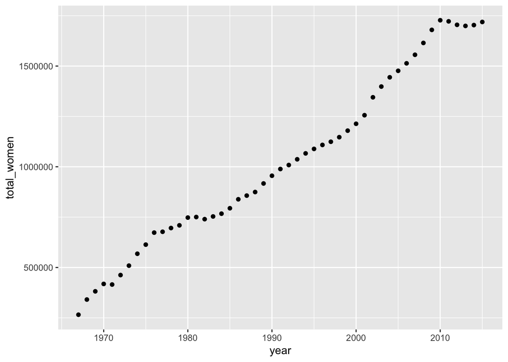

```r
#Exploritory scatter graphs

#scatter for women
grad_w_scatter <- ggplot(grad_enrollment, aes(x = year, y = total_women)) +
  geom_point()
grad_w_scatter
```

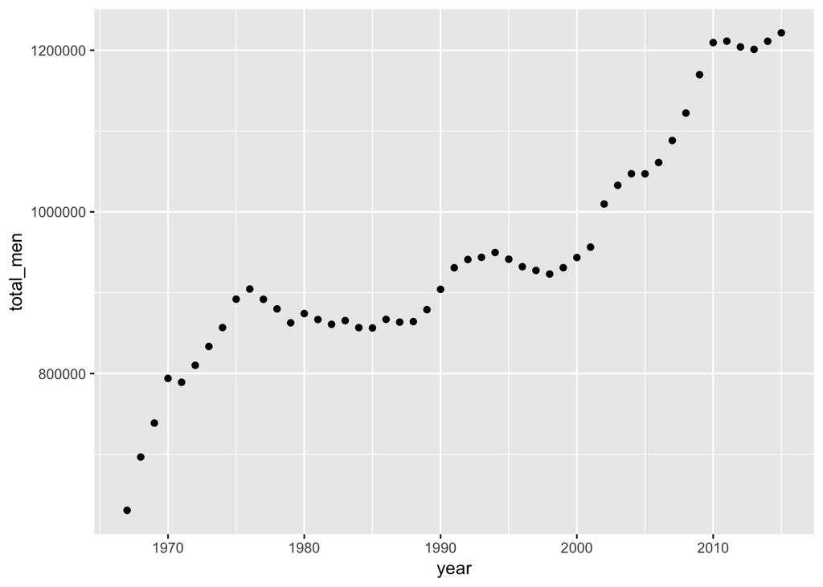

```r
#Looks good and linear

#scatter for men
grad_m_scatter <- ggplot(grad_enrollment, aes(x = year, y = total_men)) +
  geom_point()
grad_m_scatter
```

```r
#Not linear, What do we do??
```

```r
#Regression to look at total of males vs females in grad school from 1967-2015

#linear model for women
women_model <- lm(total_women ~ year, data = grad_enrollment)
women_model
```

```
##
## Call:
## lm(formula = total_women ~ year, data = grad_enrollment)
##
## Coefficients:
## (Intercept)         year
##   -58955502        30126
```

```r
summary(women_model)
```

```
##
## Call:
## lm(formula = total_women ~ year, data = grad_enrollment)
##
## Residuals:
##    Min     1Q Median     3Q    Max
## -89397 -48101  -7633  45267 129727
##
## Coefficients:
##               Estimate Std. Error t value Pr(>|t|)
## (Intercept) -5.896e+07  1.161e+06  -50.77   <2e-16 ***
## year         3.013e+04  5.832e+02   51.66   <2e-16 ***
## ---
## Signif. codes:  0 '***' 0.001 '**' 0.01 '*' 0.05 '.' 0.1 ' ' 1
##
## Residual standard error: 57730 on 47 degrees of freedom
## Multiple R-squared:  0.9827, Adjusted R-squared:  0.9823
## F-statistic:  2669 on 1 and 47 DF,  p-value: < 2.2e-16
```

```r
women_r <- cor.test(grad_enrollment$total_women, grad_enrollment$year)
women_r
```

```
##
##  Pearson's product-moment correlation
##
## data:  grad_enrollment$total_women and grad_enrollment$year
## t = 51.659, df = 47, p-value < 2.2e-16
## alternative hypothesis: true correlation is not equal to 0
## 95 percent confidence interval:
##  0.9845609 0.9951144
## sample estimates:
##       cor
## 0.9913086
```

```r
#linear model for men
men_model <- lm(total_men ~ year, data = grad_enrollment)
men_model
```

```
##
## Call:
## lm(formula = total_men ~ year, data = grad_enrollment)
##
## Coefficients:
## (Intercept)         year
##   -17112153         9069
```

```r
summary(men_model)
```

```
##
## Call:
## lm(formula = total_men ~ year, data = grad_enrollment)
##
## Residuals:
##    Min     1Q Median     3Q    Max
## -96461 -34861 -12841  51876  95766
##
## Coefficients:
##              Estimate Std. Error t value Pr(>|t|)
## (Intercept) -17112153    1087024  -15.74   <2e-16 ***
## year             9069        546   16.61   <2e-16 ***
## ---
## Signif. codes:  0 '***' 0.001 '**' 0.01 '*' 0.05 '.' 0.1 ' ' 1
##
## Residual standard error: 54050 on 47 degrees of freedom
## Multiple R-squared:  0.8545, Adjusted R-squared:  0.8514
## F-statistic:   276 on 1 and 47 DF,  p-value: < 2.2e-16
```

```r
men_r <- cor.test(grad_enrollment$total_men, grad_enrollment$year)
men_r
```

```
##
##  Pearson's product-moment correlation
##
## data:  grad_enrollment$total_men and grad_enrollment$year
## t = 16.612, df = 47, p-value < 2.2e-16
## alternative hypothesis: true correlation is not equal to 0
## 95 percent confidence interval:
##  0.8690777 0.9568547
## sample estimates:
##       cor
## 0.9243741
```

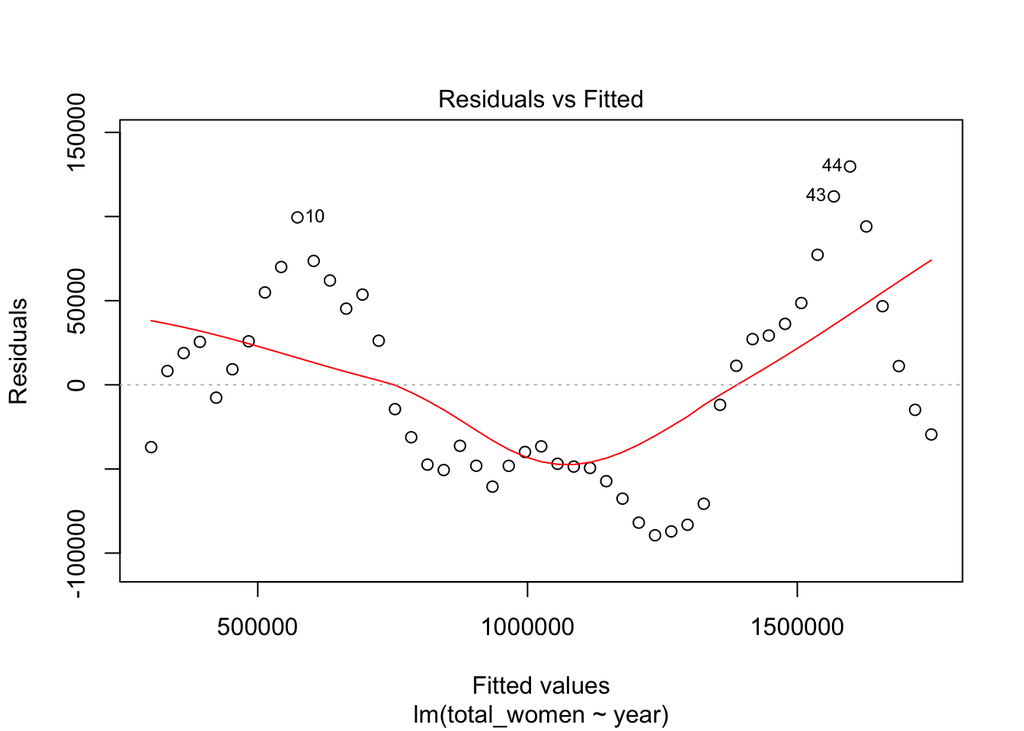

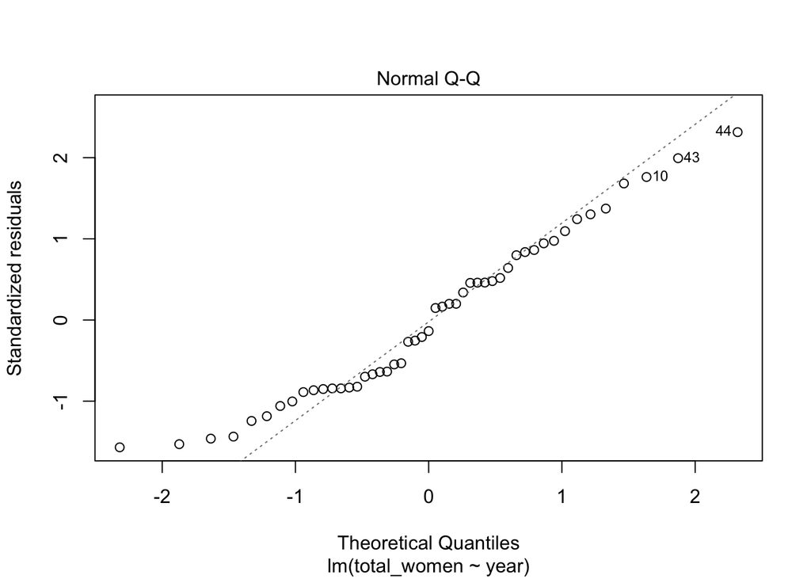

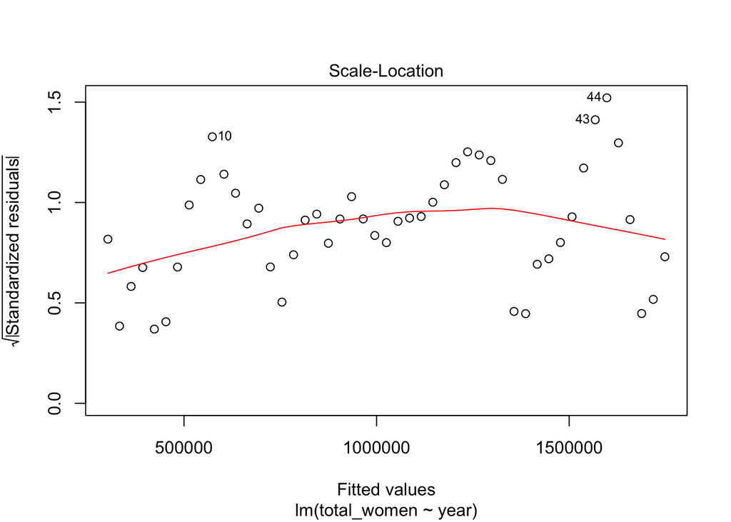

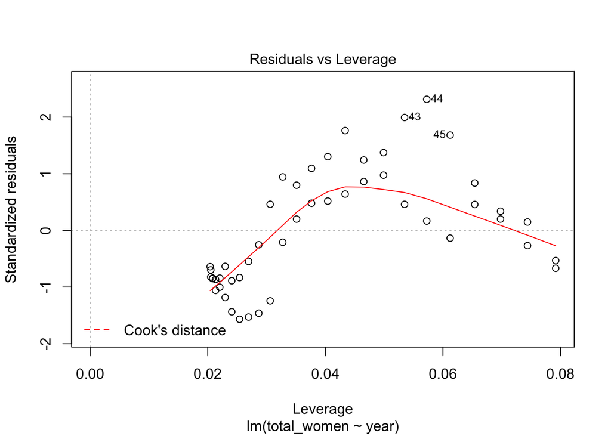

```r
#Model diagnostics
plot(women_model)
```

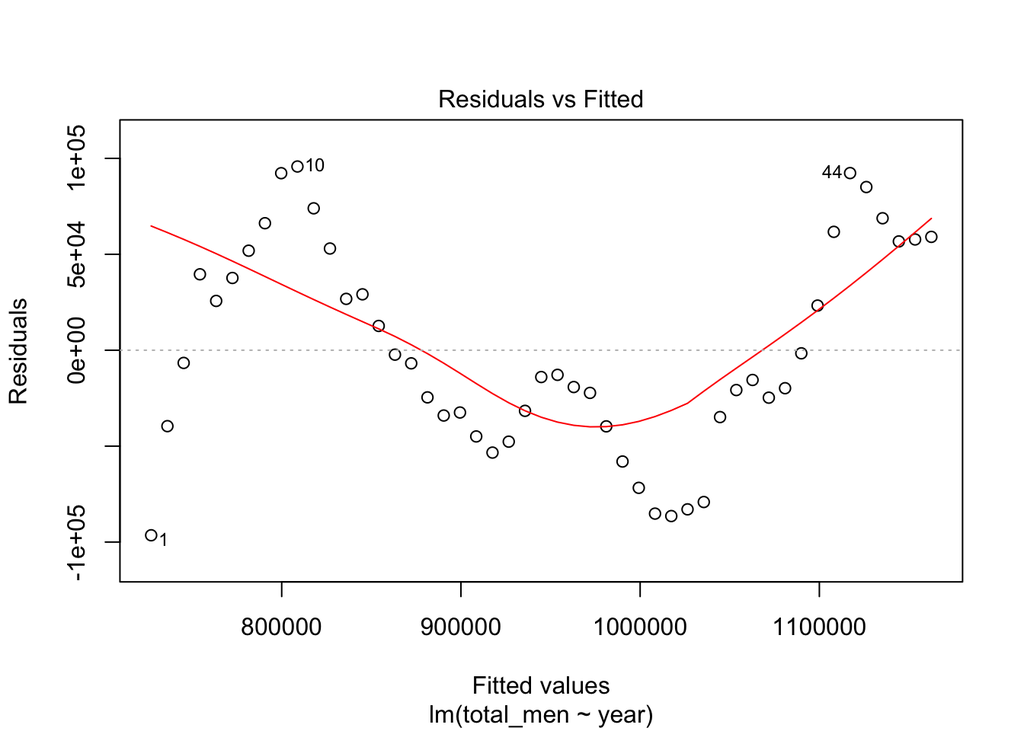

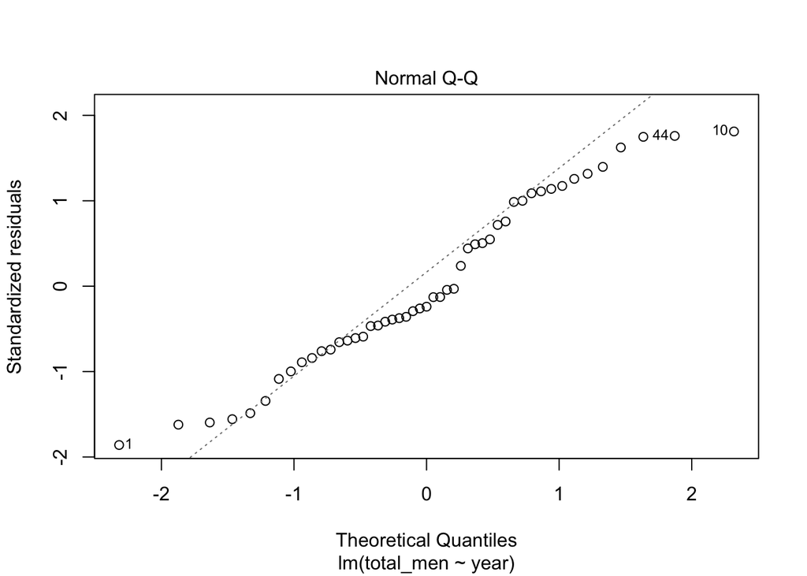

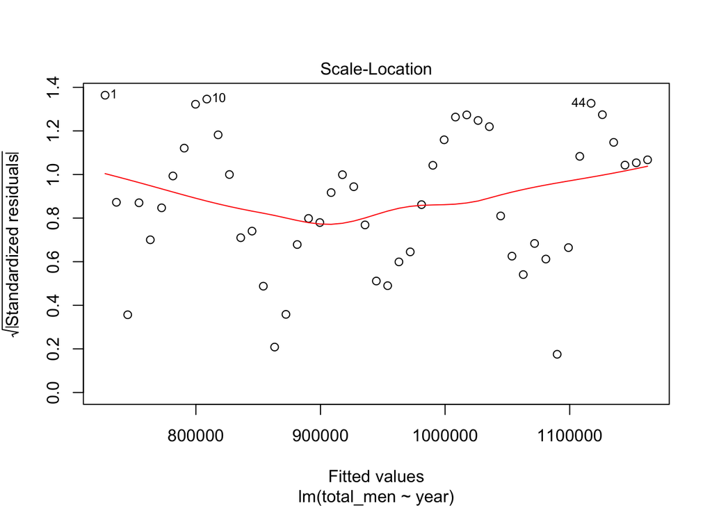

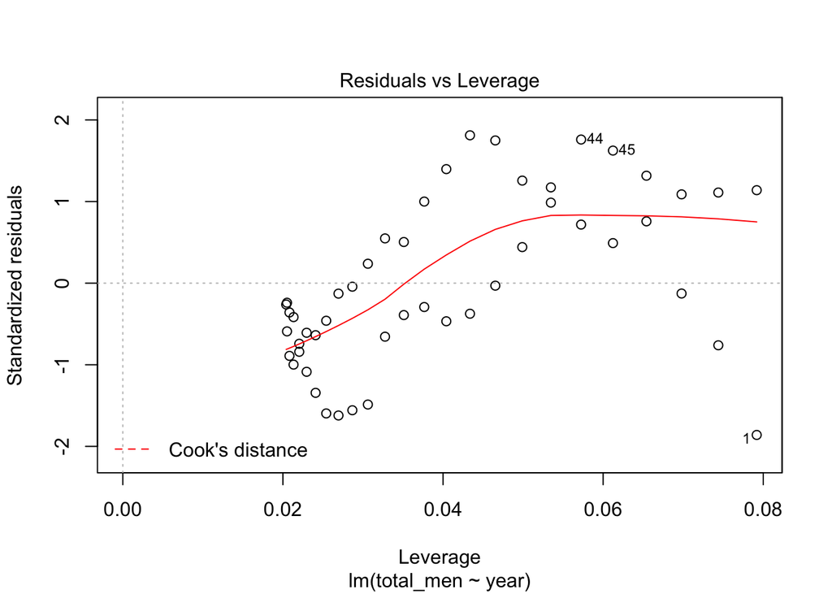

```r
plot(men_model)
```

```r
#everythig looks weird here not sure this is right!
```

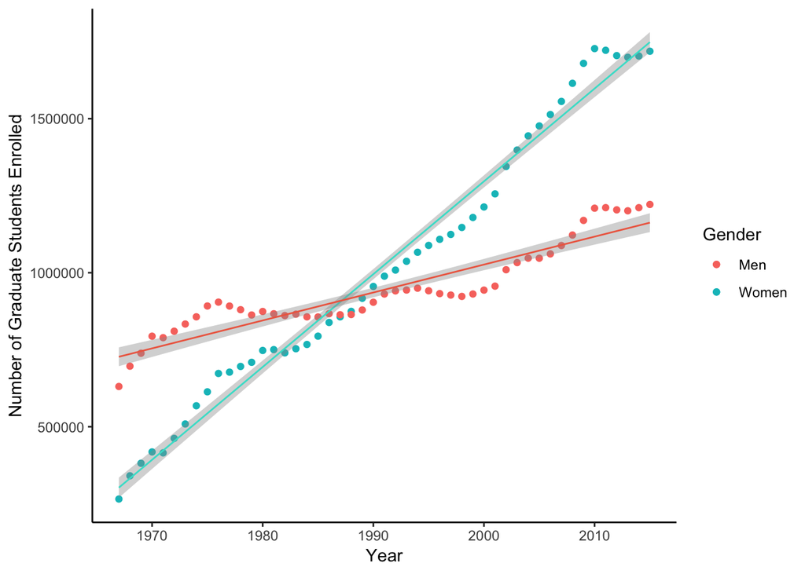

```r
#line graph
grad_enrol_graph <- ggplot(grad_enrollment, aes(year)) +
  geom_point(aes(y = total_women, color = "Women")) +
  geom_point(aes(y = total_men, color = "Men")) +
  theme_classic() +
  geom_smooth(method = lm, se = TRUE, size = 0.5, (aes(y = total_women)), color = "turquoise") +
  geom_smooth(method = lm, se = TRUE, size = 0.5, (aes(y = total_men)), color = "coral2") +
  scale_x_continuous() +
  labs(x = "Year", y = "Number of Graduate Students Enrolled")+ #need to fix ledgend and colors
  scale_color_discrete(name = "Gender", labels = c("Men", "Women"))

grad_enrol_graph
```

##2) Shifts in female PhD recipients by field (1985, 2000, and 2015). Describe if and how there was a shift in PhDs awarded to females in four fields (Physical and Earth Sciences, Engineering, Education, and Humanities & Arts) in 1985, 2000, and 2015. Describe your results statistically, in a graph or table, and in text. Note: There are several ways that you can interpret this question. You are invited to decide which you think is/are most interesting. Just be really clear about what you are asking/answering in your report.

```r
# First want to create a female subset with only years 1985, 2000, and 2015
rev_phd_field$Field_of_study_and_sex <- factor(rev_phd_field$Field_of_study_and_sex)

female_field <- filter(rev_phd_field, Field_of_study_and_sex %in% c("Female_life_sci","Female_phy_sci","Female_math","Female_ss", "Female_eng","Female_ed","Female_art","Female_other"))

# Note, I also removed "Female_all"

# Now to remove the %'s

female_absolute_field <- select(female_field, "1985_Number", "2000_Number", "2015_Number")

rownames(female_absolute_field) <- c("Female_life_sci","Female_phy_sci","Female_math","Female_ss", "Female_eng","Female_ed","Female_art","Female_other")
f_phd_prop_all <- prop.table(as.matrix(female_absolute_field), 2)

f_phd_chi_all <- chisq.test(female_absolute_field)

f_phd_chi_all
```

```
##
##  Pearson's Chi-squared test
##
## data:  female_absolute_field
## X-squared = 2898, df = 14, p-value < 2.2e-16
```

```r
# p-value = < 2.2 e -16 so DEFINETLY a significant difference
```

```r
# Making a nice table

trim_number_all <- subset(female_absolute_field, rownames(f_phd_prop_all) %in% c("Female_phy_sci","Female_eng", "Female_ed","Female_art"))

rownames(trim_number_all) <- c("Female_phy_sci","Female_eng","Female_ed","Female_art")
trim_prop_all <- subset(f_phd_prop_all, rownames(f_phd_prop_all) %in% c("Female_phy_sci","Female_eng", "Female_ed","Female_art"))

chi_table_all <- kable(trim_number_all,
                       col.name = c("1985", "2000", "2015"),
                       caption = "Changes in Fields of Study") %>%
  kable_styling(c("striped","border"))  # %>%


chi_table_all
```

Changes in Fields of Study

|  | 1985 | 2000 | 2015 |
| --- | --- | --- | --- |
| Female_phy_sci | 569 | 1022 | 1988 |
| Female_eng | 198 | 838 | 2301 |
| Female_ed | 3491 | 4179 | 3502 |
| Female_art | 1392 | 2672 | 2832 |

```r
# This run will look at just the 4 specified fields
```

```r
# I think this crunk is meaningless now...

#phd_transpose$Field_of_study_and_sex <- factor(rev_phd_field$Field_of_study_and_sex)

#female_field_t <- select(phd_transpose, Field_of_study_and_sex, #%in%
                         #"Female_life_sci","Female_phy_sci","Female_math","Female_ss", #"Female_eng","Female_ed","Female_art","Female_other")

# Note, I also removed "Female_all"

# Now to remove the %'s

#female_absolute_field_t <- filter(female_field_t,Field_of_study_and_sex %in% c("1985_Number", "2000_Number", "2015_Number"))

#rownames(female_absolute_field_t) <- c("1985_Number","2000_Number", "2015_Number")

#phd_f_row <- select(female_absolute_field_t, "Female_life_sci":"Female_other")

#f_phd_t_prop_all <- prop.table(as.matrix(phd_f_row), 3)

#f_phd_t_chi_all <- chisq.test(female_absolute_field_t)

#f_phd_chi_all
```

3. Male and female salaries for starting postdoctoral and other employment positions (2015). Compare median salaries for male and female doctorate recipients in 2015. Answer these two questions:Does median salary differ significantly between male and female starting postdoc positions? Does median salary differ significantly between male and female PhD recipients in non-postdoc employment positions?

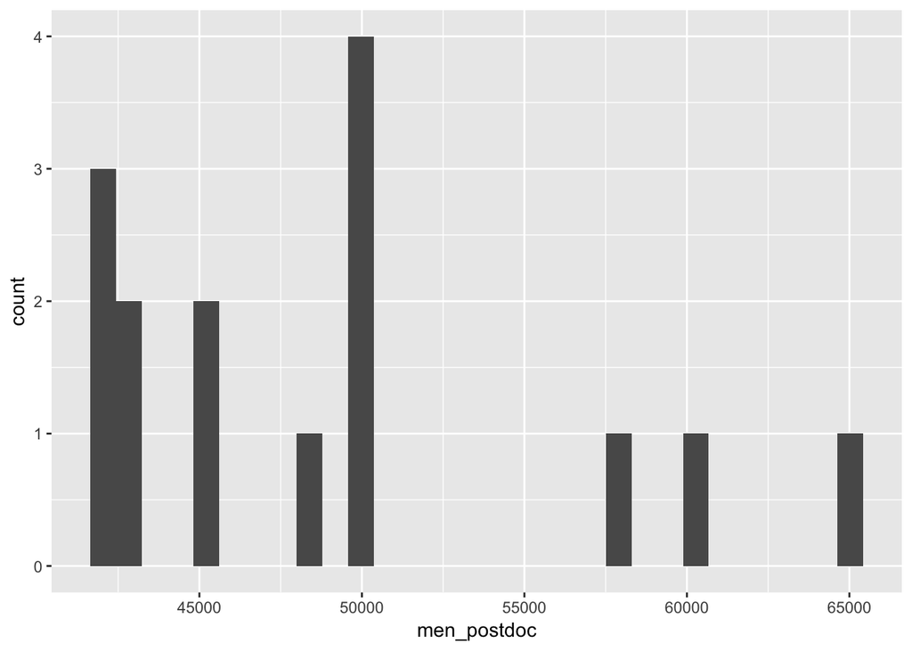

```r
post_doc_hist = ggplot(doctoral_salary, aes(x = men_postdoc))+
  geom_histogram()
post_doc_hist
```

```r
post_doc_qq = ggplot(doctoral_salary, aes(x = men_postdoc))+
  geom_qq()
#post_doc_qq
```

```r
#var.test(doctoral_salary$men_employment,doctoral_salary$women_employment) #Variances are not equal
#var.test(doctoral_salary$men_postdoc,doctoral_salary$women_postdoc) #Variances are not equal

non_post_doc_test = wilcox.test(doctoral_salary$men_employment,doctoral_salary$women_employment, paired = TRUE)
post_doc_test = wilcox.test(doctoral_salary$men_postdoc,doctoral_salary$women_postdoc, paired = TRUE)
post_doc_test
```

```
##
##  Wilcoxon signed rank test with continuity correction
##
## data:  doctoral_salary$men_postdoc and doctoral_salary$women_postdoc
## V = 19.5, p-value = 0.8884
## alternative hypothesis: true location shift is not equal to 0
```

```r
non_post_doc_test
```

```
##
##  Wilcoxon signed rank test with continuity correction
##
## data:  doctoral_salary$men_employment and doctoral_salary$women_employment
## V = 101, p-value = 0.002572
## alternative hypothesis: true location shift is not equal to 0
```

```r
#Starting the linear model
salary_mod_1 = lm(salary~sex+years_faculty_service+years_since_PhD+faculty_rank+discipline, data = faculty_salary)
summary(salary_mod_1)
```

```
##
## Call:
## lm(formula = salary ~ sex + years_faculty_service + years_since_PhD +
##     faculty_rank + discipline, data = faculty_salary)
##
## Residuals:
##    Min     1Q Median     3Q    Max
## -65248 -13211  -1775  10384  99592
##
## Coefficients:
##                       Estimate Std. Error t value Pr(>|t|)
## (Intercept)            78862.8     4990.3  15.803  < 2e-16 ***
## sexMale                 4783.5     3858.7   1.240  0.21584
## years_faculty_service   -489.5      211.9  -2.310  0.02143 *
## years_since_PhD          535.1      241.0   2.220  0.02698 *
## faculty_rankAsstProf  -12907.6     4145.3  -3.114  0.00198 **
## faculty_rankProf       32158.4     3540.6   9.083  < 2e-16 ***
## disciplineB            14417.6     2342.9   6.154 1.88e-09 ***
## ---
## Signif. codes:  0 '***' 0.001 '**' 0.01 '*' 0.05 '.' 0.1 ' ' 1
##
## Residual standard error: 22540 on 390 degrees of freedom
## Multiple R-squared:  0.4547, Adjusted R-squared:  0.4463
## F-statistic:  54.2 on 6 and 390 DF,  p-value: < 2.2e-16
```

```r
salary_mod_1
```

```
##
## Call:
## lm(formula = salary ~ sex + years_faculty_service + years_since_PhD +
##     faculty_rank + discipline, data = faculty_salary)
##
## Coefficients:
##           (Intercept)                sexMale  years_faculty_service
##               78862.8                 4783.5                 -489.5
##       years_since_PhD   faculty_rankAsstProf       faculty_rankProf
##                 535.1               -12907.6                32158.4
##           disciplineB
##               14417.6
```

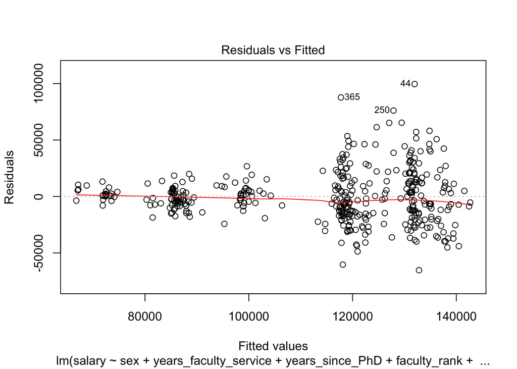

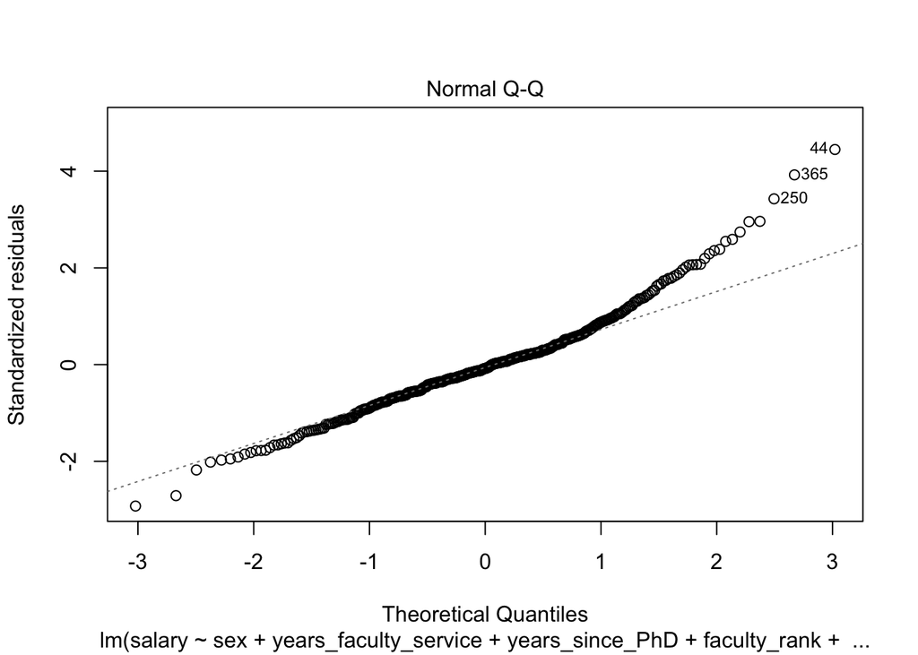

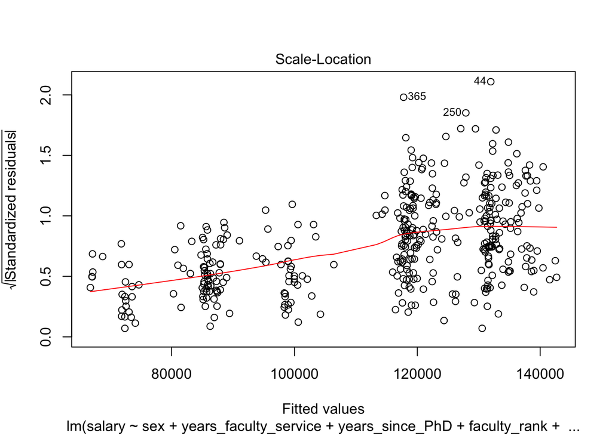

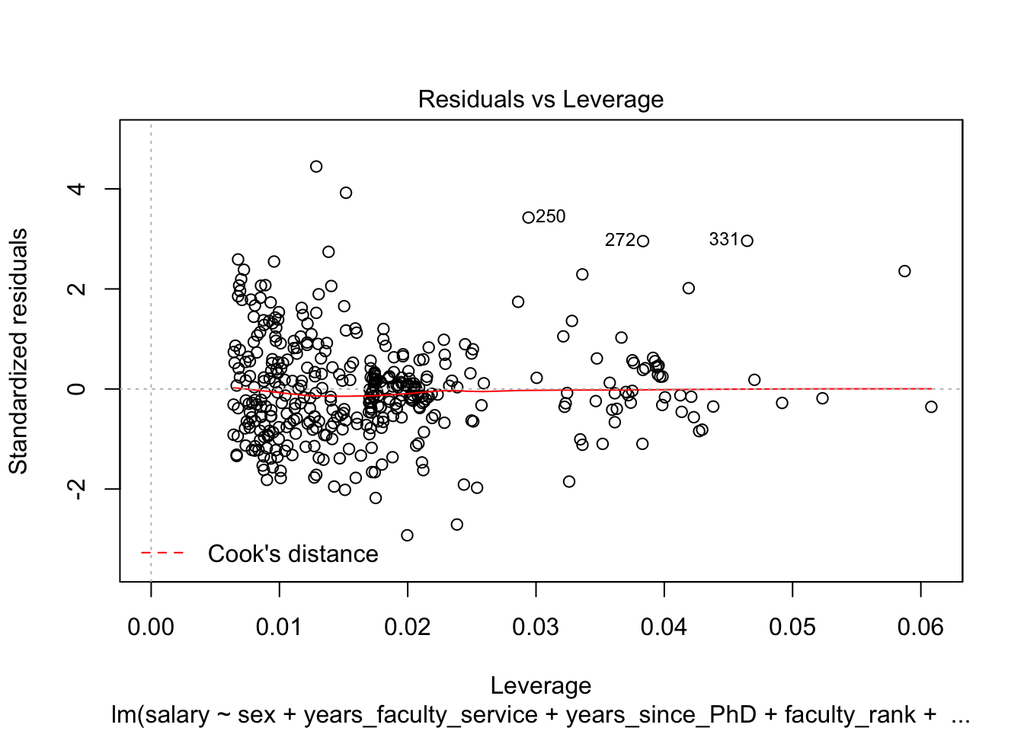

```r
#Assistant professors < Acossiate professors < Full professor
plot(salary_mod_1)
```

```r
#hmmm it seems there is some heterdasicity, it also has some issues with residual normality
vif(salary_mod_1)
```

```
##                           GVIF Df GVIF^(1/(2*Df))
## sex                   1.030805  1        1.015285
## years_faculty_service 5.923038  1        2.433729
## years_since_PhD       7.518936  1        2.742068
## faculty_rank          2.013193  2        1.191163
## discipline            1.064105  1        1.031555
```

```r
AIC(salary_mod_1)
```

```
## [1] 9093.826
```

```r
#Making a model that excludes years
salary_mod_2 = lm(salary~sex+faculty_rank+discipline, data = faculty_salary)
summary(salary_mod_2)
```

```
##
## Call:
## lm(formula = salary ~ sex + faculty_rank + discipline, data = faculty_salary)
##
## Residuals:
##    Min     1Q Median     3Q    Max
## -66268 -14127  -1566  10813  97718
##
## Coefficients:
##                      Estimate Std. Error t value Pr(>|t|)
## (Intercept)             81947       4506  18.187  < 2e-16 ***
## sexMale                  4492       3860   1.164 0.245291
## faculty_rankAsstProf   -13723       3959  -3.466 0.000586 ***
## faculty_rankProf        33680       3177  10.600  < 2e-16 ***
## disciplineB             13709       2295   5.972 5.25e-09 ***
## ---
## Signif. codes:  0 '***' 0.001 '**' 0.01 '*' 0.05 '.' 0.1 ' ' 1
##
## Residual standard error: 22640 on 392 degrees of freedom
## Multiple R-squared:  0.4469, Adjusted R-squared:  0.4412
## F-statistic: 79.18 on 4 and 392 DF,  p-value: < 2.2e-16
```

```r
AIC(salary_mod_2)
```

```
## [1] 9095.454
```

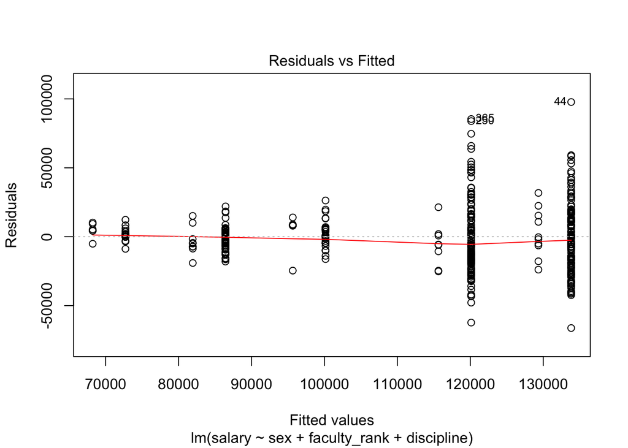

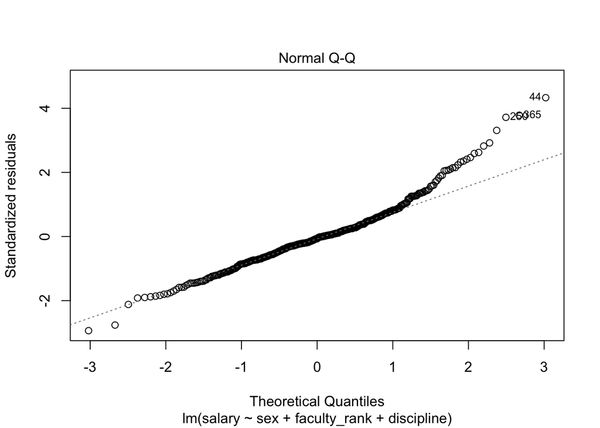

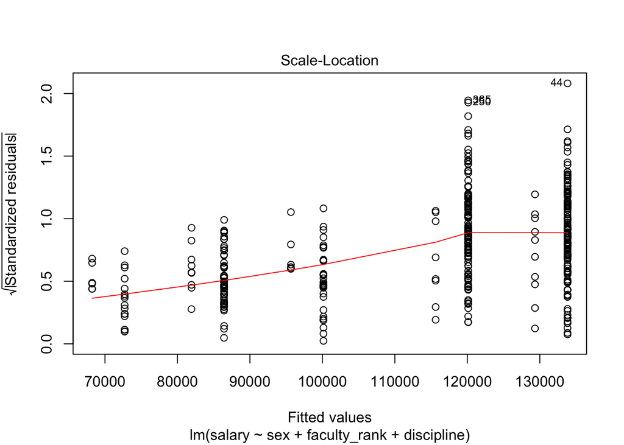

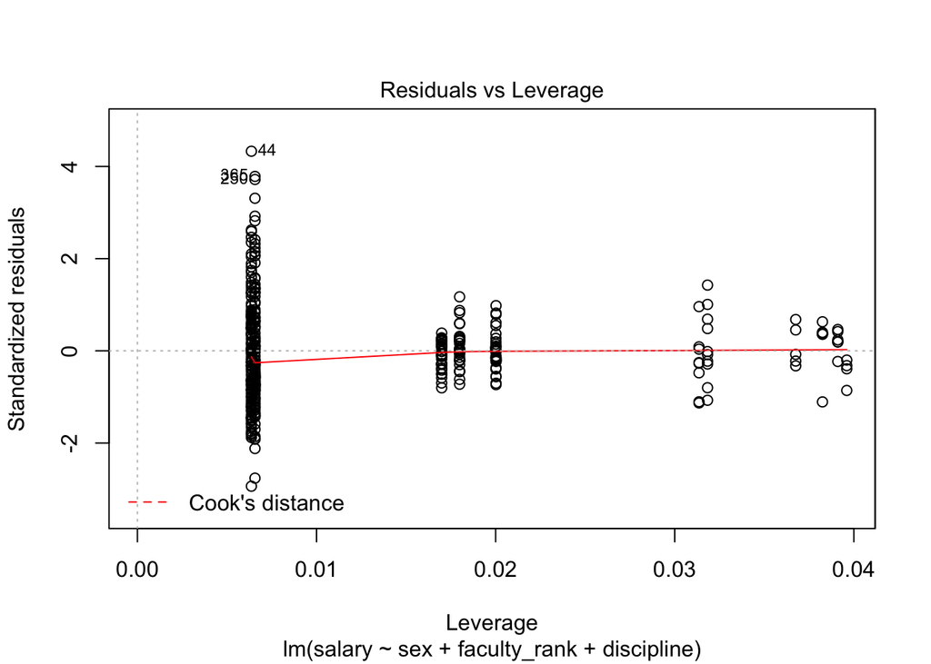

```r
plot(salary_mod_2)
```

```r
vif(salary_mod_2)
```

```
##                  GVIF Df GVIF^(1/(2*Df))
## sex          1.022339  1        1.011108
## faculty_rank 1.034437  2        1.008500
## discipline   1.012236  1        1.006099
```

```r
salary_mod_3 = lm(salary~sex+faculty_rank+years_faculty_service+discipline, data = faculty_salary)
summary(salary_mod_3)
```

```
##
## Call:
## lm(formula = salary ~ sex + faculty_rank + years_faculty_service +
##     discipline, data = faculty_salary)
##
## Residuals:
##    Min     1Q Median     3Q    Max
## -64202 -14255  -1533  10571  99163
##
## Coefficients:
##                        Estimate Std. Error t value Pr(>|t|)
## (Intercept)            82912.07    4668.39  17.760  < 2e-16 ***
## sexMale                 4771.25    3878.00   1.230 0.219311
## faculty_rankAsstProf  -14560.40    4098.32  -3.553 0.000428 ***
## faculty_rankProf       34599.24    3382.52  10.229  < 2e-16 ***
## years_faculty_service    -88.78     111.64  -0.795 0.426958
## disciplineB            13473.38    2315.50   5.819 1.24e-08 ***
## ---
## Signif. codes:  0 '***' 0.001 '**' 0.01 '*' 0.05 '.' 0.1 ' ' 1
##
## Residual standard error: 22650 on 391 degrees of freedom
## Multiple R-squared:  0.4478, Adjusted R-squared:  0.4407
## F-statistic: 63.41 on 5 and 391 DF,  p-value: < 2.2e-16
```

```r
AIC(salary_mod_3)
```

```
## [1] 9096.813
```

```r
vif(salary_mod_3)
```

```
##                           GVIF Df GVIF^(1/(2*Df))
## sex                   1.030803  1        1.015284
## faculty_rank          1.597441  2        1.124233
## years_faculty_service 1.627110  1        1.275582
## discipline            1.029040  1        1.014416
```

```r
faculty_sal_acoc = faculty_salary %>%
  filter(faculty_rank == "AssocProf")
faculty_sal_asst = faculty_salary %>%
  filter(faculty_rank == "AsstProf")
faculty_sal_prof = faculty_salary %>%
  filter(faculty_rank == "Prof")
```

```r
constillations = stargazer(salary_mod_2, type = "html")
```

|  | *Dependent variable:* |
| --- | --- |
|  | salary |
| sexMale | 4,491.801 |
|  | (3,860.240) |
| faculty_rankAsstProf | -13,723.420*** |
|  | (3,959.014) |
| faculty_rankProf | 33,679.900*** |
|  | (3,177.338) |
| disciplineB | 13,708.690*** |
|  | (2,295.437) |
| Constant | 81,946.950*** |
|  | (4,505.769) |
| Observations | 397 |
| R<sup>2</sup> | 0.447 |
| Adjusted R<sup>2</sup> | 0.441 |
| Residual Std. Error | 22,640.990 (df = 392) |
| F Statistic | 79.180*** (df = 4; 392) |
| *Note:* | p<0.1; p<0.05; p<0.01 |

```r
constillations
```

[output not shown]

```r
salary_mod_4 = lm(salary~sex+years_since_PhD+faculty_rank+discipline, data = faculty_salary)
vif(salary_mod_4)
```

```
##                     GVIF Df GVIF^(1/(2*Df))
## sex             1.028359  1        1.014080
## years_since_PhD 2.065517  1        1.437191
## faculty_rank    1.987205  2        1.187301
## discipline      1.055727  1        1.027486
```

```r
summary(salary_mod_4)
```

```
##
## Call:
## lm(formula = salary ~ sex + years_since_PhD + faculty_rank +
##     discipline, data = faculty_salary)
##
## Residuals:
##    Min     1Q Median     3Q    Max
## -67451 -13860  -1549  10716  97023
##
## Coefficients:
##                       Estimate Std. Error t value Pr(>|t|)
## (Intercept)           80988.47    4931.84  16.422  < 2e-16 ***
## sexMale                4349.37    3875.39   1.122  0.26242
## years_since_PhD          61.01     127.01   0.480  0.63124
## faculty_rankAsstProf -13104.15    4167.31  -3.145  0.00179 **
## faculty_rankProf      32928.40    3544.40   9.290  < 2e-16 ***
## disciplineB           13937.47    2346.53   5.940 6.32e-09 ***
## ---
## Signif. codes:  0 '***' 0.001 '**' 0.01 '*' 0.05 '.' 0.1 ' ' 1
##
## Residual standard error: 22660 on 391 degrees of freedom
## Multiple R-squared:  0.4472, Adjusted R-squared:  0.4401
## F-statistic: 63.27 on 5 and 391 DF,  p-value: < 2.2e-16
```

```r
AIC(salary_mod_4)
```

```
## [1] 9097.22
```

```r
salary_mod_5 = lm(salary~sex+years_faculty_service+faculty_rank+discipline+years_faculty_service*faculty_rank, data = faculty_salary)
summary(salary_mod_5)
```

```
##
## Call:
## lm(formula = salary ~ sex + years_faculty_service + faculty_rank +
##     discipline + years_faculty_service * faculty_rank, data = faculty_salary)
##
## Residuals:
##    Min     1Q Median     3Q    Max
## -65007 -14267  -1367  10853  98612
##
## Coefficients:
##                                            Estimate Std. Error t value
## (Intercept)                                 85621.2     5666.0  15.112
## sexMale                                      4748.7     3886.3   1.222
## years_faculty_service                        -313.7      283.3  -1.107
## faculty_rankAsstProf                       -19680.3     6839.7  -2.877
## faculty_rankProf                            31081.2     5380.1   5.777
## disciplineB                                 13471.4     2318.4   5.811
## years_faculty_service:faculty_rankAsstProf   1249.3     1888.4   0.662
## years_faculty_service:faculty_rankProf        261.4      307.5   0.850
##                                            Pr(>|t|)
## (Intercept)                                 < 2e-16 ***
## sexMale                                     0.22248
## years_faculty_service                       0.26878
## faculty_rankAsstProf                        0.00423 **
## faculty_rankProf                           1.56e-08 ***
## disciplineB                                1.30e-08 ***
## years_faculty_service:faculty_rankAsstProf  0.50864
## years_faculty_service:faculty_rankProf      0.39585
## ---
## Signif. codes:  0 '***' 0.001 '**' 0.01 '*' 0.05 '.' 0.1 ' ' 1
##
## Residual standard error: 22680 on 389 degrees of freedom
## Multiple R-squared:  0.4492, Adjusted R-squared:  0.4393
## F-statistic: 45.33 on 7 and 389 DF,  p-value: < 2.2e-16
```